# Team 12 - Hot Cocoa Codesters Project 1

Grace Chang, Seungwan Kim, Riley C Maher, Sage O’Toole, Jenna Kay Probst

2/21/2021

# 1 Setup

```r
library(ggplot2) #Calls ggplot
library(dplyr)
hotels <- read.csv("hotel_bookings.csv", stringsAsFactors = TRUE) #Reads in Hotel Bookings Data
hotels$is_canceled <- as.factor(hotels$is_canceled)
```

# 2 General Analysis

## 2.1 Arrival Distribution

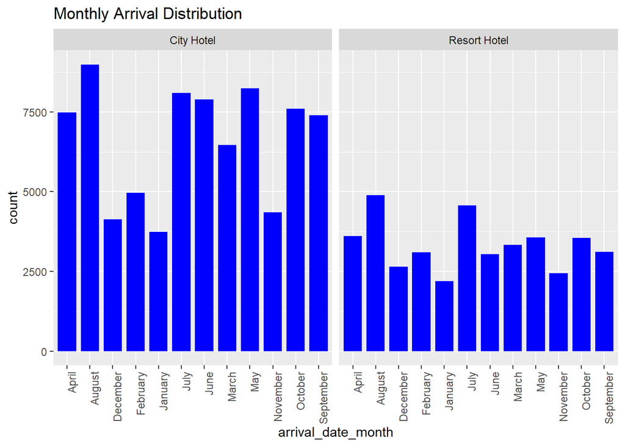

```r
ggplot(hotels, aes(x = arrival_date_month)) +
  geom_bar(width = 0.8, fill="blue") +
  facet_wrap(~hotel) +
  labs(title = "Monthly Arrival Distribution") +
  theme(axis.text.x = element_text(angle = 90, hjust = 1)) #Produces barplot of arrivals by month for each hotel
```

When looking towards the monthly distribution for both hotels, the City Hotel peaks in the summer and has lulls in late autumn and winter. The Resort Hotel follows a similar, yet less volatile pattern.

```r
hotels$seasons <- ifelse(hotels$arrival_date_month == "December"|
                                hotels$arrival_date_month == "January"|
                                hotels$arrival_date_month == "February",
                                "Winter",
                          ifelse(hotels$arrival_date_month == "March"|
                                 hotels$arrival_date_month == "April"|
                                 hotels$arrival_date_month == "May",
                                "Spring",
                          ifelse(hotels$arrival_date_month == "June"|
                                 hotels$arrival_date_month == "July"|
                                 hotels$arrival_date_month == "August",
                                "Summer",
                                "Autumn")))
sample_n(hotels, 10)
```

```
##           hotel is_canceled lead_time arrival_date_year arrival_date_month
## 1    City Hotel           1       337              2015          September
## 2    City Hotel           0         0              2016              April
## 3    City Hotel           0        10              2015           November
## 4  Resort Hotel           0       322              2016               June
## 5  Resort Hotel           0         2              2016            October
## 6    City Hotel           1       396              2017               June
## 7    City Hotel           0        51              2017                May
## 8    City Hotel           1       111              2017              April
## 9    City Hotel           1       188              2016               June
## 10   City Hotel           1       129              2017            January
##    arrival_date_week_number arrival_date_day_of_month stays_in_weekend_nights
## 1                        38                        19                       2
## 2                        15                         9                       0
## 3                        46                        14                       2
```

[output cut: 73 more lines]

```r
seasons <- table(hotels$season)
seasons <- round(prop.table(seasons),digits=3)
seasons[4]
```

```
## Winter
##  0.174
```

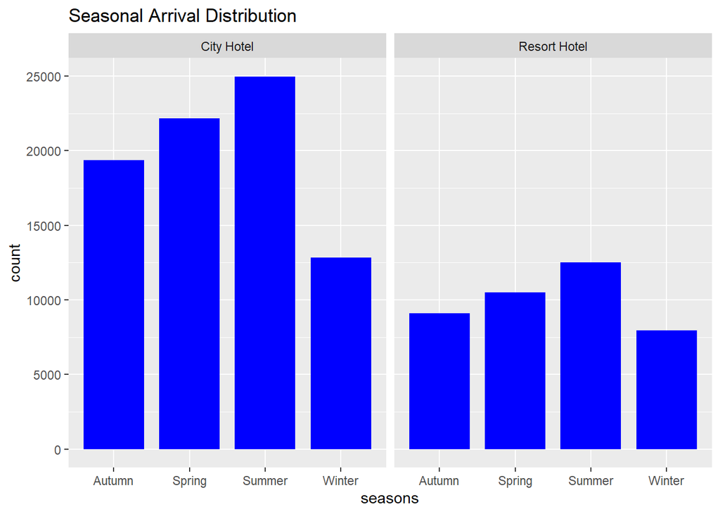

```r
ggplot(hotels, aes(seasons)) + geom_bar(width = 0.8, fill="blue") +facet_wrap(~hotel) + labs(title = "Seasonal Arrival Distribution") #Produces barplot of arrivals by season for each hotel
```

This bar chart depicts another visual of the seasonal changes in arrivals for both hotels. Again, both hotels see the most arrivals in summer and the least in winter. (Approximately 0.314 of bookings in the summer, and 0.174 in the winter).The city hotel sees more drastic changes than the resort hotel as seen on the previous monthly distribution bar plot.

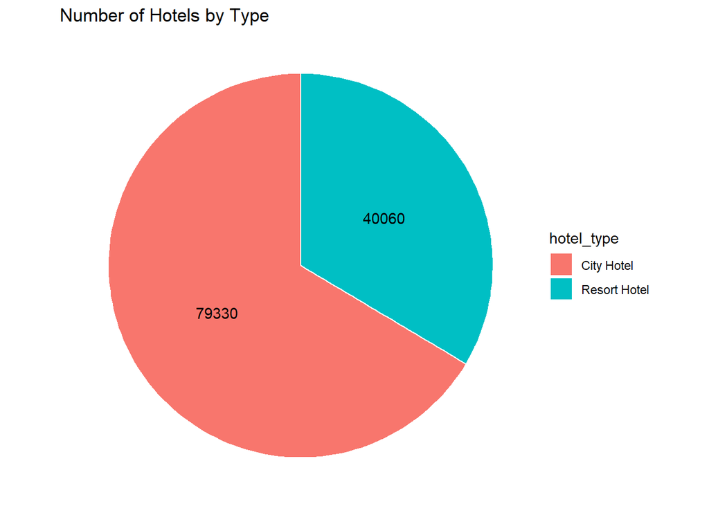

```r
# Finding the types of hotels
hotel_types <- data.frame(table(hotels$hotel))
hotel_types <- hotel_types %>%
  rename(hotel_type = Var1, number_of_hotels = Freq)
# Creating a pie chart of hotel types
ggplot(hotel_types, aes(x="", y=number_of_hotels, fill=hotel_type)) +
  geom_bar(width = 1, stat = "identity", color = "white") +
  coord_polar('y', start = 0) +
  geom_text(aes(y = number_of_hotels, label=number_of_hotels), position=position_stack(vjust=0.5), color = "black") +
  theme_void() +
  labs(title = "Number of Hotels by Type")
```

# 3 Exploring Cancellation

```r
total_cancel_rate <- round(NROW(hotels$is_canceled[hotels$is_canceled == 1])/NROW(hotels$is_canceled), 3)*100 #Returns proportion of bookings that were canceled
total_cancel_rate
```

```
## [1] 37
```

```r
cancel_prop <- round(prop.table(table(hotels$hotel, hotels$is_canceled),1)*100, 3) #Calculates cancellation rates for each hotel
cancel_prop
```

```
##
##                     0      1
##   City Hotel   58.273 41.727
##   Resort Hotel 72.237 27.763
```

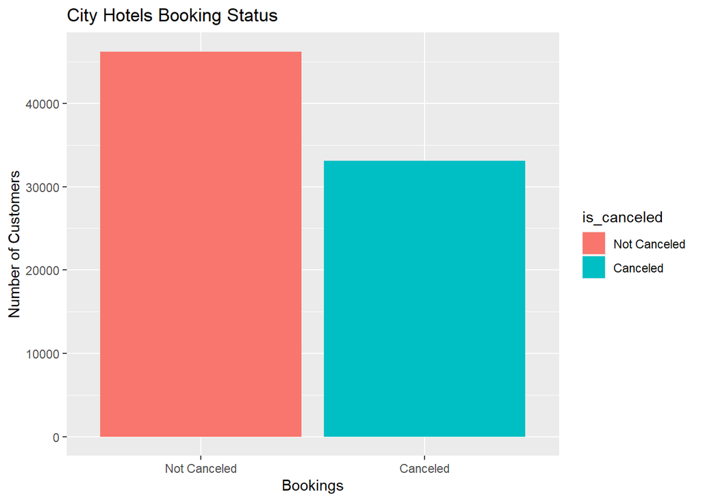

```r
city_canceled <- filter(hotels, hotel == "City Hotel")
city_hotel <- ggplot(city_canceled, aes(x=is_canceled)) +
  geom_bar(aes(fill=is_canceled)) +
  scale_x_discrete(labels=c("Not Canceled", "Canceled")) +
  scale_fill_discrete(labels=c("Not Canceled", "Canceled")) +
  labs(y = "Number of Customers", x = "Bookings" , title = "City Hotels Booking Status") #Graph to show the city hotel cancellation
city_hotel
```

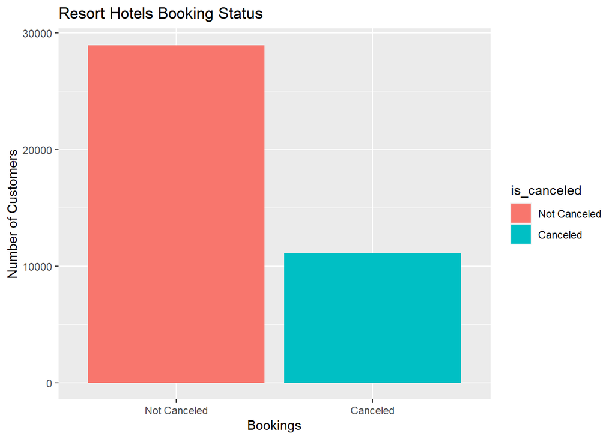

```r
resort_canceled <- filter(hotels, hotel == "Resort Hotel")
resort_hotel <- ggplot(resort_canceled, aes(x=is_canceled)) +
  geom_bar(aes(fill=is_canceled) ) +
  scale_x_discrete(labels=c("Not Canceled", "Canceled")) +
  scale_fill_discrete(labels=c("Not Canceled", "Canceled")) +
  labs(y = "Number of Customers", x = "Bookings" , title = "Resort Hotels Booking Status") #Graph to show the resort hotel cancellation
resort_hotel
```

While the overall rate of cancellation is 37%, the cancellation rate for City Hotels is slightly higher at 41.727% and the cancellation rate for Resort Hotels is slightly lower at 27.763%.

## 3.1 Lead Time

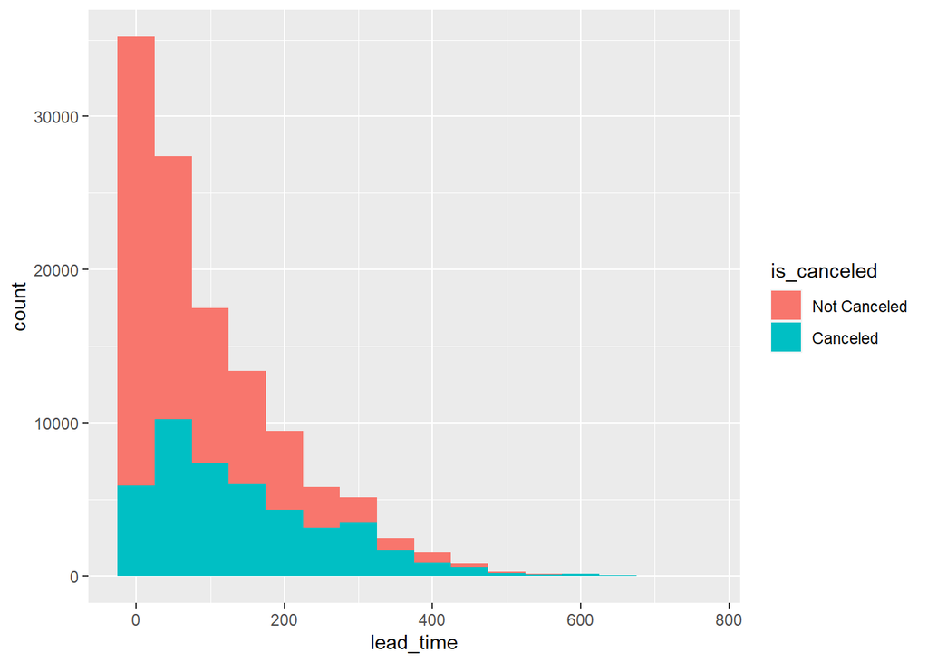

```r
ggplot(hotels, aes(x=lead_time, fill= is_canceled)) +
  scale_fill_discrete(labels=c("Not Canceled", "Canceled")) +
  geom_histogram(binwidth = 50) #Dist of lead time separated by cancellation
```

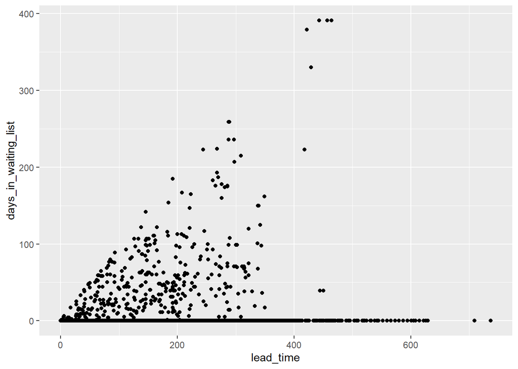

```r
ggplot(hotels, aes(x = lead_time, y = days_in_waiting_list)) +
  geom_point() # point plot to show the relationship between days in waiting list and lead time
```

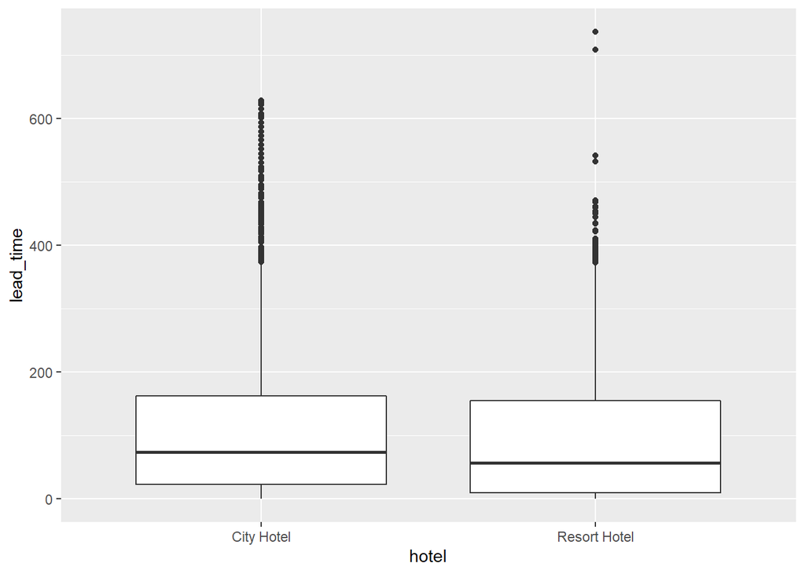

```r
lead_by_hotel <- ggplot(hotels, aes(x=hotel, y=lead_time))
lead_by_hotel + geom_boxplot() # Box plot to show the lead time by the hotel types
```

## 3.2 Market Segmentation & Type and Distribution Channel

```r
round(prop.table(table(hotels$market_segment, hotels$is_canceled),1), 3) #Calculates cancellation rates by market segment
```

```
##
##                     0     1
##   Aviation      0.781 0.219
##   Complementary 0.869 0.131
##   Corporate     0.813 0.187
##   Direct        0.847 0.153
##   Groups        0.389 0.611
##   Offline TA/TO 0.657 0.343
##   Online TA     0.633 0.367
##   Undefined     0.000 1.000
```

```r
round(prop.table(table(hotels$customer_type, hotels$is_canceled),1), 3) #Calculates cancellation by customer type
```

```
##
##                       0     1
##   Contract        0.690 0.310
##   Group           0.898 0.102
##   Transient       0.593 0.407
##   Transient-Party 0.746 0.254
```

```r
round(prop.table(table(hotels$distribution_channel,
                       hotels$is_canceled),1), 3) #Calculates cancellation rates by Channel
```

```
##
##                 0     1
##   Corporate 0.779 0.221
##   Direct    0.825 0.175
##   GDS       0.808 0.192
##   TA/TO     0.590 0.410
##   Undefined 0.200 0.800
```

## 3.3 Deposit Type

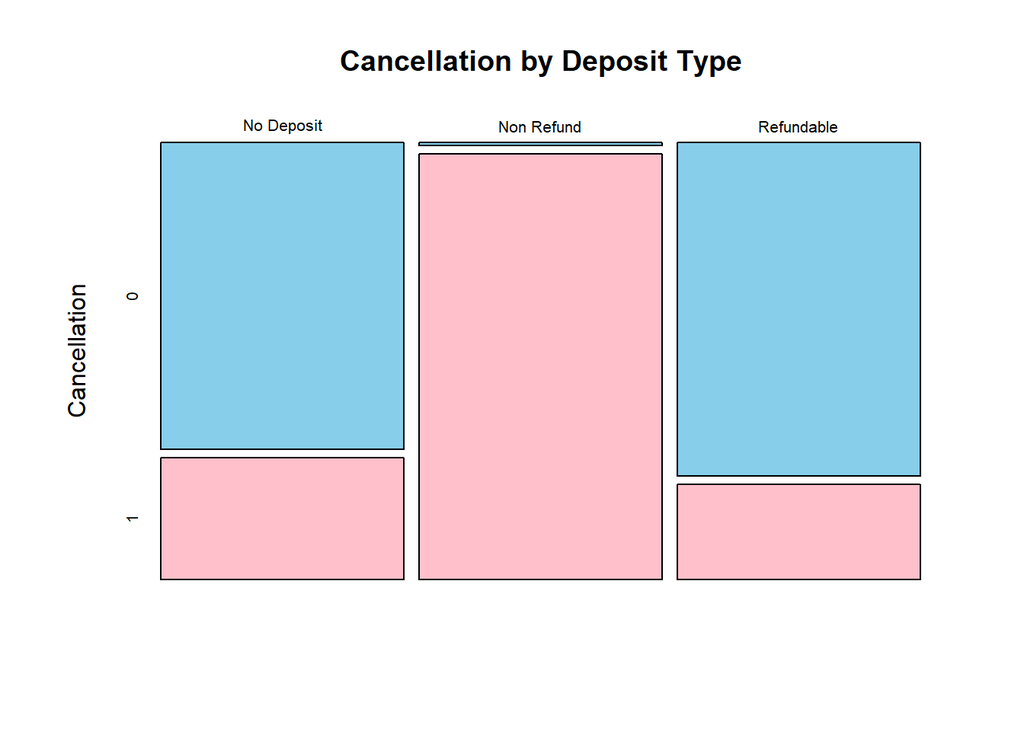

```r
deposit_cancel <- round(prop.table(table(hotels$deposit_type,
                                         hotels$is_canceled),1), 3) #Calculates cancellation rates by deposit type

plot(round(prop.table(table(hotels$deposit_type, hotels$is_canceled),1), 3),
     main="Cancellation by Deposit Type",
     ylab = "Cancellation",
     col=c("sky blue", "pink"))
```

```r
#Graphs cancellation rates by deposit type
```

The cancellation rates for each deposit type is incredibly interesting. Among those with non-refundable deposits almost all of those customers ended up canceling their room, about 0.994. This made us doubt that the data was labeled incorrectly, but found in a Kaggle discussion post that the author of the paper, which the data set is from, addressed this issue: “…through analysis of the “Nonrefundable” (Deposit Type) canceled bookings in some Asiatic countries (Country) and from certain distribution channels (Distribution Channel and Agent), it is possible to understand why so many “Nonrefundable” bookings are canceled. These bookings are usually made through OTA using false or invalid credit card details. These bookings are issued as support for requests for visas to enter the country (a hotel booking is mandatory for applying for a Portuguese entry visa)." This is important information to consider when forecasting demand to make demand-management decisions.

## 3.4 Past Customer Behavior

```r
repeat_cancel <- round(prop.table(table(hotels$is_repeated_guest, hotels$is_canceled),1), 3) #Calculates cancellation rates based on if they are repeat guest
round(prop.table(table(hotels$previous_cancellations, hotels$is_canceled),1), 3) #Calculates cancellation rates based on number of past canceled stays
```

```
##
##          0     1
##   0  0.661 0.339
##   1  0.056 0.944
##   2  0.672 0.328
##   3  0.692 0.308
##   4  0.774 0.226
##   5  0.895 0.105
##   6  0.682 0.318
##   11 0.714 0.286
##   13 0.083 0.917
##   14 0.000 1.000
##   19 0.000 1.000
##   21 0.000 1.000
##   24 0.000 1.000
##   25 0.000 1.000
##   26 0.000 1.000
```

```r
table(hotels$previous_cancellations) #Calculates number of entries for each number of previous cancellations (Note that this isn't perfect since some cancellations likely happened within and outside of the cancellation period resulting in double counting of some people)
```

```
##
##      0      1      2      3      4      5      6     11     13     14     19
## 112906   6051    116     65     31     19     22     35     12     14     19
##     21     24     25     26
##      1     48     25     26
```

As expected the cancellation rate of customers who have previously stayed in the hotels is lower than those who haven’t; by about half (0.378 vs 0.145). Surprisingly, those who have had 1 previous cancellations have a higher rate of cancellation, but for those with 2-11 cancellations the rate is actually lower than people with no cancellations. It is quite interesting that those with more than 14 cancellations have a cancellation rate of 100%, you would not expect people to make this many bookings (up to 26) to cancel every single time.

## 3.5 Exploring Arrival Times & Monthly cancellations

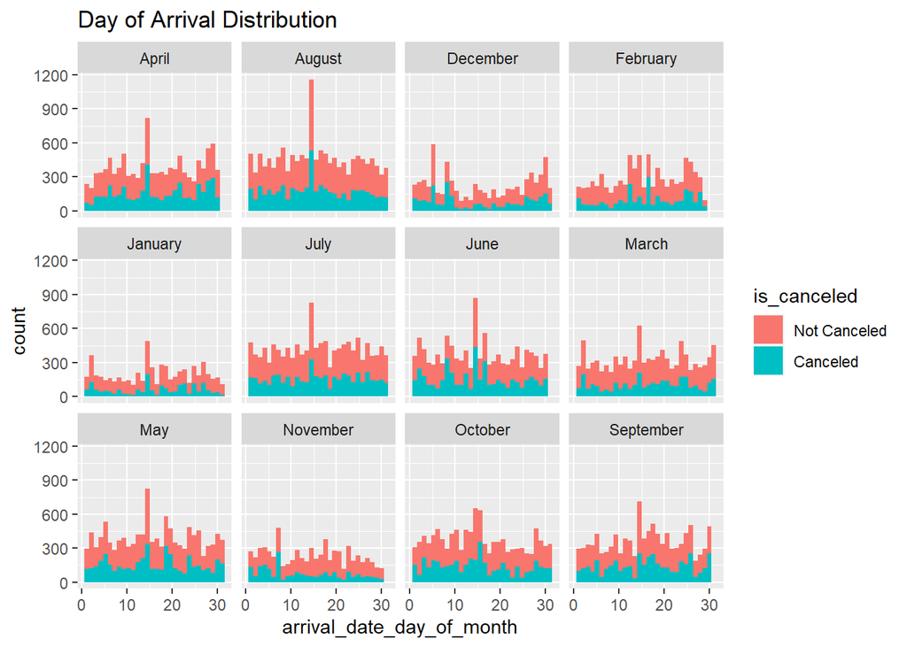

```r
ggplot(hotels, aes(x=arrival_date_day_of_month, fill =is_canceled)) +
  geom_histogram() +
  facet_wrap(~arrival_date_month) +
  scale_fill_discrete(labels=c("Not Canceled", "Canceled")) +
  labs(title = "Day of Arrival Distribution") #produces histograms of day of arrival for each month
```

```r
month_cancel <- round(prop.table(table(hotels$arrival_date_month, hotels$is_canceled),1), 3) #Calculates cancellation rates by month
month_cancel
```

```
##
##                 0     1
##   April     0.592 0.408
##   August    0.622 0.378
##   December  0.650 0.350
##   February  0.666 0.334
##   January   0.695 0.305
##   July      0.625 0.375
##   June      0.585 0.415
##   March     0.678 0.322
##   May       0.603 0.397
##   November  0.688 0.312
##   October   0.620 0.380
##   September 0.608 0.392
```

```r
#Choose not to do distribution by year due to incomplete data for 2015 & 2017
```

The day of month distribution for each month is interesting, showing that in a majority of the months, arrivals peak between the tenth and twentieth. It should be noted that the separation of the cancellation shows that the cancellations follow the pattern of arrivals, as in when more people are set to arrive, more cancellations occur. The proportion table affirms this finding and is provided to show the exact range of cancellation rates for each month; with a range of 0.305 ~ 0.415 of bookings are canceled each month, there appears to be little variation among the rates per month.

## 3.6 Booking Changes

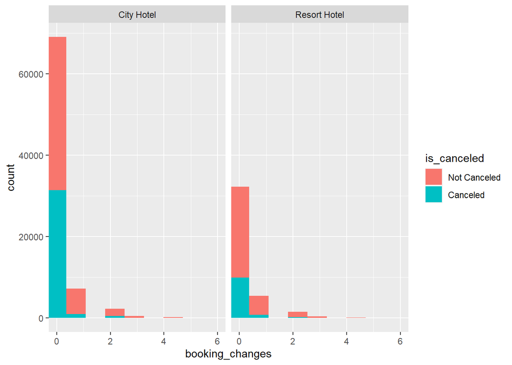

```r
ggplot(hotels, aes(x=booking_changes, fill = is_canceled)) +
  geom_histogram() +
  facet_wrap(~hotel) +
  coord_cartesian(xlim = c(0,6)) +
  scale_fill_discrete(labels=c("Not Canceled", "Canceled"))
```

Above are histograms showing the count of bookings by number of booking changes for each hotel. We see that with each hotel, the vast majority of bookings are not changed. The distribution appear to both be skewed right.

# 4 Exploring Booking Details

## 4.1 Adults, Children, & Babies

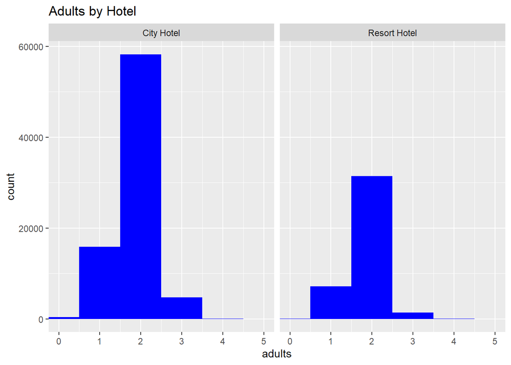

```r
hotels$guests <- hotels$adults + hotels$children + hotels$babies #creates parameter of all guests on booking
ggplot(data=hotels, aes(adults)) +
  geom_histogram(binwidth = 1, fill="blue") +
  coord_cartesian(xlim = c(0,5))+facet_wrap(~hotel) +
  labs(title = "Adults by Hotel")
```

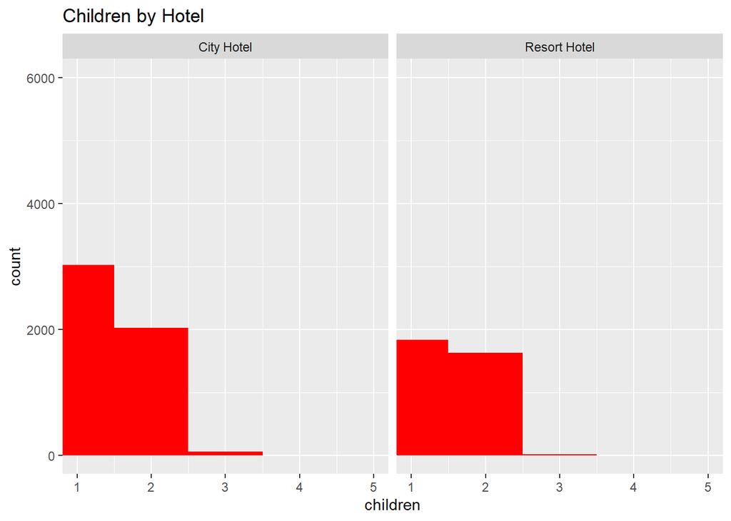

```r
#Histogram of number adults for each hotel
ggplot(data=hotels, aes(children)) +
  geom_histogram(binwidth = 1, fill="red") +
  coord_cartesian(xlim = c(1,5), ylim = c(0,6000))+facet_wrap(~hotel) +
  labs(title="Children by Hotel")
```

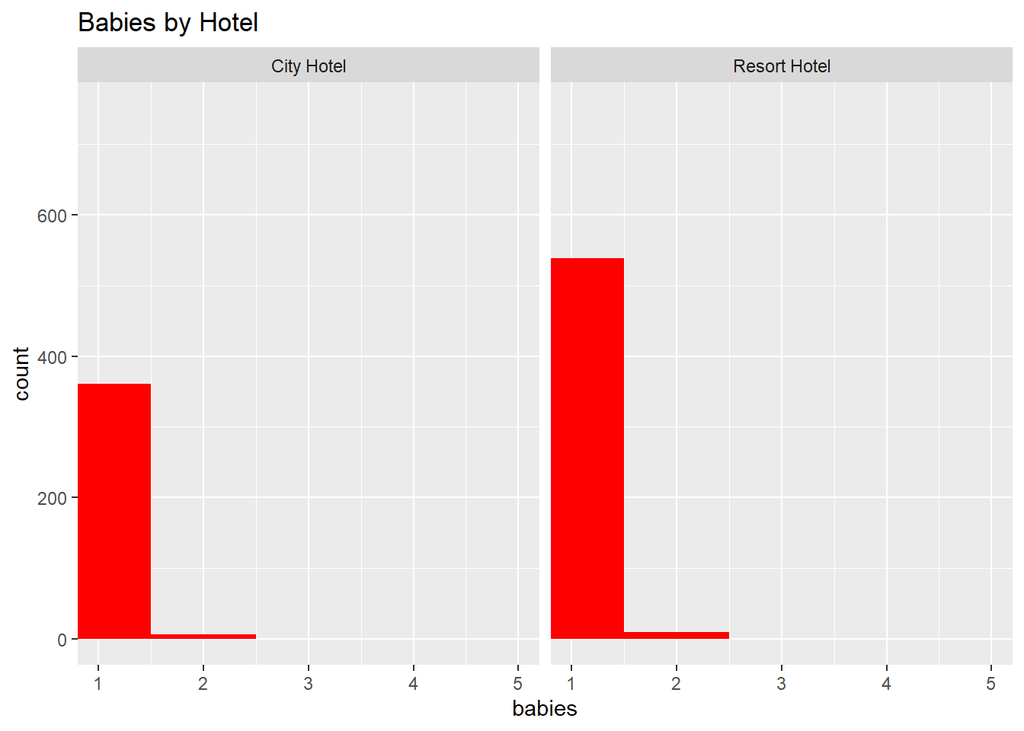

```r
#Histogram of number children for each hotel
ggplot(data=hotels, aes(babies)) +
  geom_histogram(binwidth = 1, fill="red") +
  coord_cartesian(xlim = c(1,5), ylim = c(0,750))+facet_wrap(~hotel) +
  labs(title="Babies by Hotel")
```

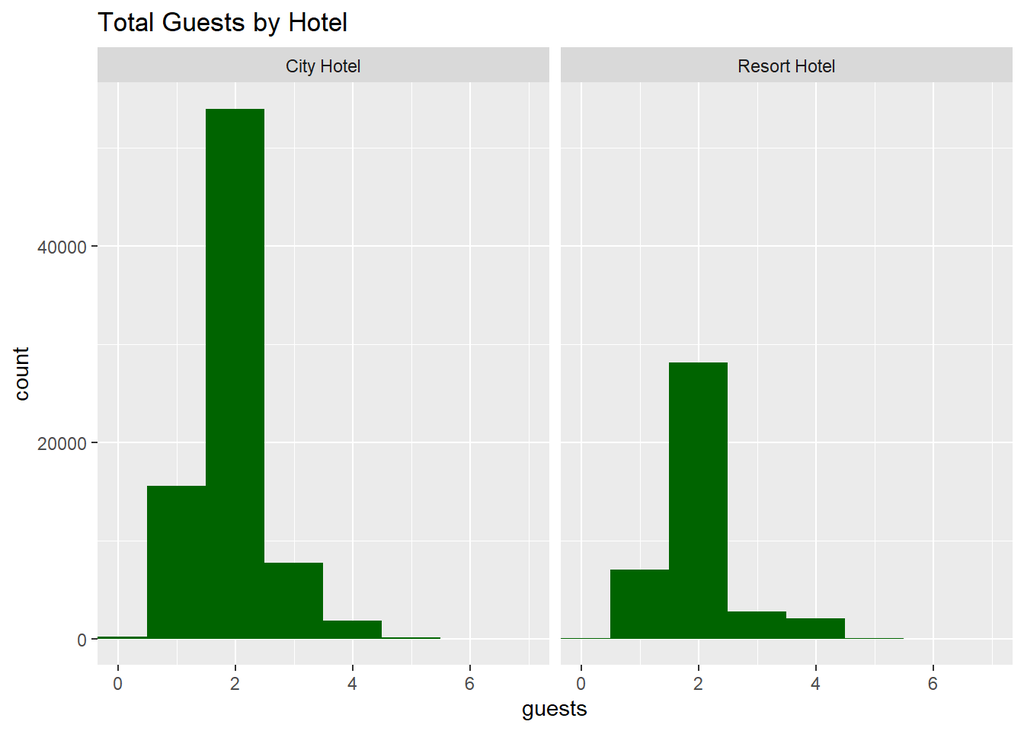

```r
#Histogram of number babies for each hotel
ggplot(data=hotels, aes(guests)) +geom_histogram(binwidth = 1, fill="dark green") +
  coord_cartesian(xlim = c(0,7)) +
  facet_wrap(~hotel) +
  labs(title="Total Guests by Hotel")
```

```r
#Histogram of total number of guests for each hotel
```

Above are histograms for the number of adults, children, babies, and all guests total for each hotel. Overwhelmingly the most common amount of adults is two, likely indicating that people typically travel as a couple or partnership. Since such a large portion of people travel without children or babies, the children and babies histograms start at 1. Most bookings with children only have 1, while the proportion of people have two children is much closer to one child for the resort hotel, possibly due to more people traveling to the resort for non-business purposes. For babies, it is overwhelmingly dominated by having only one baby for a booking. Besides the number of children distinction already mentioned, the distributions for each hotel are quite similar.

### 4.1.1 Relationships between Adults & Children and Parking Spots Needed & Guests

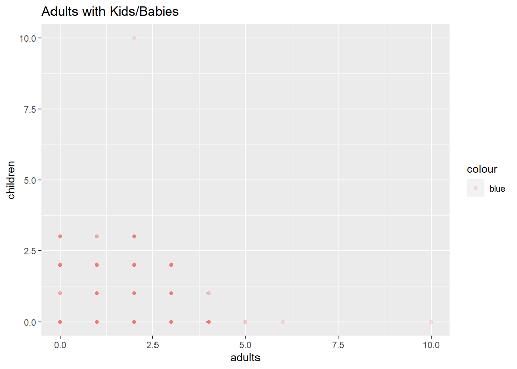

```r
ggplot(data = hotels, aes(x=adults, y =children, color = "blue")) +
  geom_point(alpha=1/5) +
  coord_cartesian(xlim = c(0,10)) +
  labs(title='Adults with Kids/Babies') #creates scatter plot of number of adults and children on bookings
```

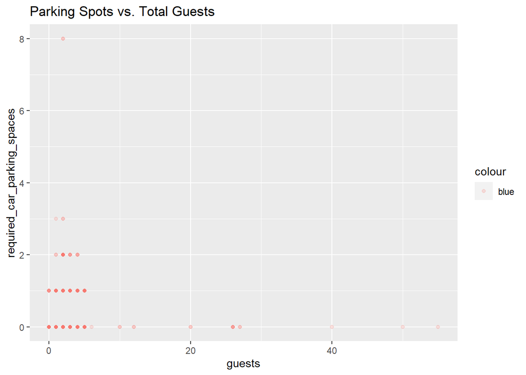

```r
ggplot(data =hotels, aes(x=guests, y=required_car_parking_spaces, color = "blue")) +
  geom_point(alpha=1/5) +
  labs(title='Parking Spots vs. Total Guests')#creates scatter plot of guests & number of parking spots required
```

Above the scatter plots are provided comparing the relationship between adults and children as well as the amount of guests on a booking and the amount of parking spots requested. As you can see, neither relationship appears to have significant patterns. It is interesting to note that for large amounts of guests, parking spots are not requested past ~8 guests.

## 4.2 Meals

```r
# Seeing the type of meals families with kids buy
kids <- hotels %>%
  filter(children > 1)
meals_with_kids <- data.frame(table(kids$meal))
meals_with_kids <- meals_with_kids %>%
  mutate(meal_percent = round(Freq / nrow(kids), 3)*100) %>%
  rename(meal_type = Var1, number_of_meals = Freq)
meals_with_kids
```

```
##   meal_type number_of_meals meal_percent
## 1        BB            3183         85.4
## 2        FB              12          0.3
## 3        HB             489         13.1
## 4        SC              31          0.8
## 5 Undefined              14          0.4
```

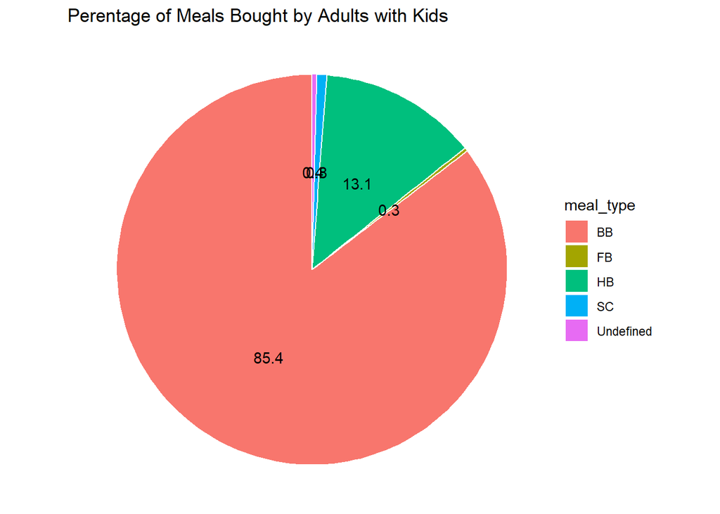

```r
ggplot(meals_with_kids, aes(x="", y=meal_percent, fill=meal_type)) +
  geom_bar(width = 1, stat = "identity", color = "white") +
  coord_polar('y', start = 0) +
  geom_text(aes(y = meal_percent, label=meal_percent), position=position_stack(vjust=0.5), color = "black") +
  theme_void() +
  labs(title = "Perentage of Meals Bought by Adults with Kids")
```

```r
# Seeing the type of meals families with no kids buy
no_kids <- hotels %>%
  filter(children == 0)
meals_with_no_kids <- data.frame(table(no_kids$meal))
meals_with_no_kids <- meals_with_no_kids %>%
  mutate(meal_percent = round(Freq / nrow(no_kids), 3)*100) %>%
  rename(meal_type = Var1, number_of_meals = Freq)
meals_with_no_kids
```

```
##   meal_type number_of_meals meal_percent
## 1        BB           85227         76.9
## 2        FB             732          0.7
## 3        HB           13217         11.9
## 4        SC           10494          9.5
## 5 Undefined            1126          1.0
```

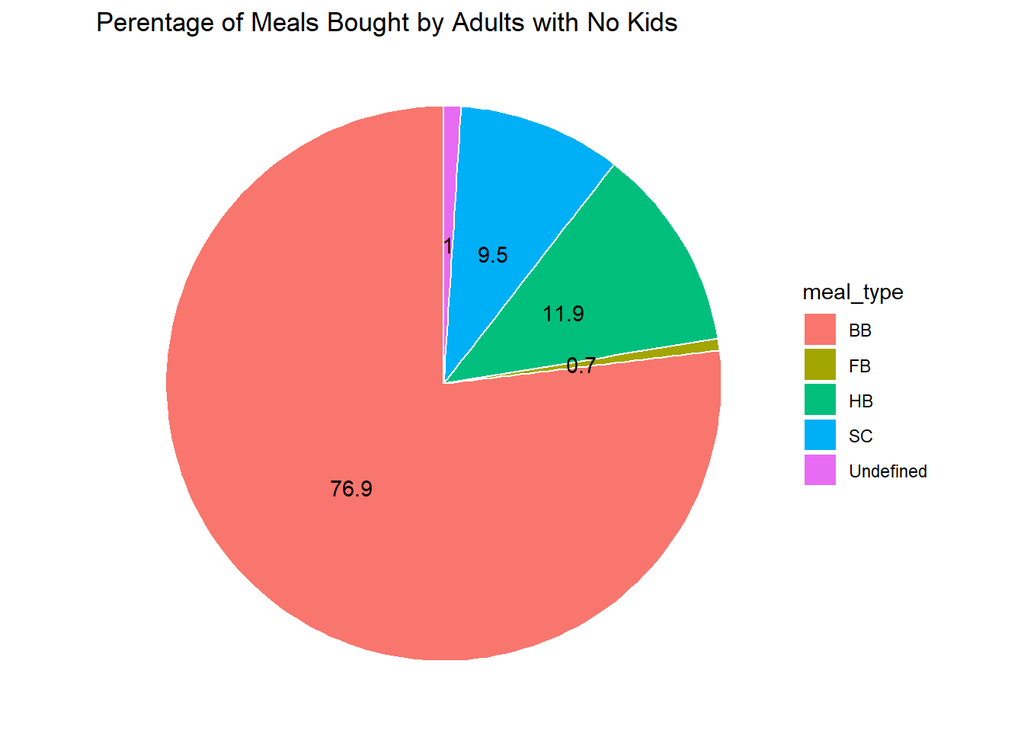

```r
ggplot(meals_with_no_kids, aes(x="", y=meal_percent, fill=meal_type)) +
  geom_bar(width = 1, stat = "identity", color = "white") +
  coord_polar('y', start = 0) +
  geom_text(aes(y = meal_percent, label=meal_percent), position=position_stack(vjust=0.5), color = "black") +
  theme_void() +
  labs(title = "Perentage of Meals Bought by Adults with No Kids")
```

## 4.3 Agent Bookings

```r
# Calculating the average daily rate of bookings that did/didn't use an agent
mean_adr_agent <- hotels %>%
  filter(agent != 'NULL') %>%
  summarize(mean_adr_agent = round(mean(adr, na.rm = TRUE), 2))
mean_adr_no_agent <- hotels %>%
  filter(agent == 'NULL') %>%
  summarize(mean_adr_no_agent = round(mean(adr, na.rm = TRUE), 2))

mean_adr_agent
```

```
##   mean_adr_agent
## 1         104.62
```

```r
mean_adr_no_agent
```

```
##   mean_adr_no_agent
## 1             84.25
```

These numbers show us that people who booked with an agent actually paid more per night on average than those that did not book with an agent. If you used an agent, you would have paid $104.62 while if you did not use an agent, you would have paid $84.25.

## 4.4 Room Types

```r
table(hotels$reserved_room_type[hotels$hotel== "City Hotel"])
```

```
##
##     A     B     C     D     E     F     G     H     L     P
## 62595  1115    14 11768  1553  1791   484     0     0    10
```

```r
table(hotels$reserved_room_type[hotels$hotel== "Resort Hotel"])
```

```
##
##     A     B     C     D     E     F     G     H     L     P
## 23399     3   918  7433  4982  1106  1610   601     6     2
```

```r
hotels$reserved_room_type <- as.numeric(hotels$reserved_room_type)
hotels$assigned_room_type <- as.numeric(hotels$assigned_room_type)
hotels$RoomAquired <- ifelse(hotels$reserved_room_type == hotels$assigned_room_type,1,0)
acquired <- round(prop.table(table(hotels$hotel, hotels$RoomAquired), 1), 3)
acquired
```

```
##
##                    0     1
##   City Hotel   0.091 0.909
##   Resort Hotel 0.193 0.807
```

As seen above, neither hotel has a 100% record for assigning guests to the rooms they reserved, with Resort Hotel having a slightly worse success rate of 0.807 vs 0.909.

## 4.5 Special Requests

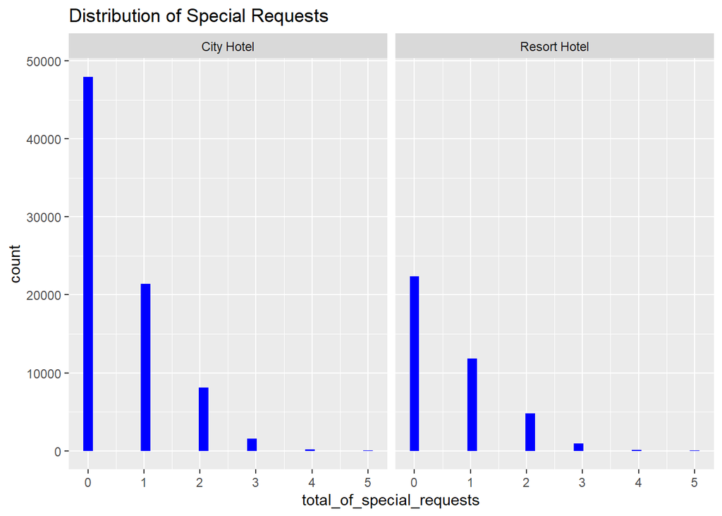

```r
ggplot(data = hotels, aes(total_of_special_requests)) + geom_histogram(fill="blue") + facet_wrap(~hotel) + labs(title="Distribution of Special Requests")
```

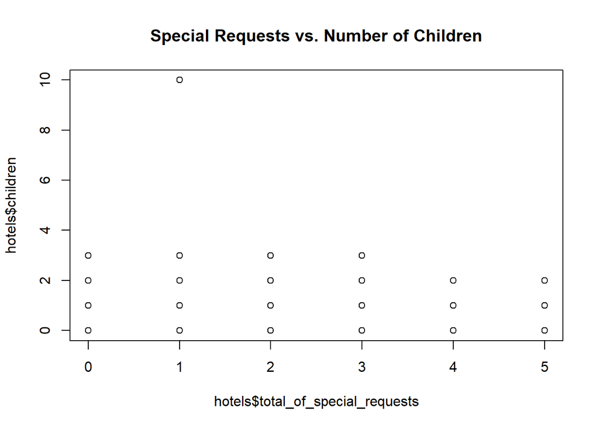

```r
plot(hotels$total_of_special_requests,hotels$children, main="Special Requests vs. Number of Children")
```

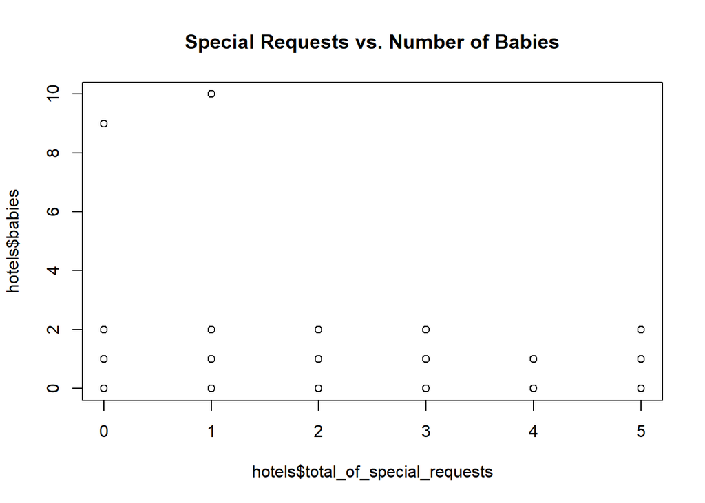

```r
plot(hotels$total_of_special_requests,hotels$babies, main="Special Requests vs. Number of Babies")
```

Both hotels have similar distributions of special requests made, with most guests making 0 and a very small amount making more than 4. Neither amount of children or babies have a strong relationship with the amount of requests made.

# 5 Conclusion

## 5.2 Business Implication

- Hotels have insight into customers’ meal preferences and room preferences, which will help hotels consider package options and conduct events to attract customers to generate more revenue.
- Resort hotels tend to have less bookings than city hotels, so they will need to work on their marketing. This under the assumption that both hotel types have the same capacity.
- Hotels can conduct additional research, such as a TA/TO survey, to gain insight into why customers who booked a room through agents have a higher cancellation rate. It will help them analyze the booking rates and potential income.
- Most customers travel alone or in pairs so the hotels could advertise in ways that attract couples as well as business travelers.
- City hotels could sell more non-refundable bookings during peak times or apply stricter refund policies to prevent revenue loss from the cancellations.
- Since June-August happens to be the busiest months, hotels should target more customers during this time by providing more value package options to maximize the revenue than in the other months.